# Assignment 4

Candidate number: 23498

Word count: 742

## Introduction

The purpose of this report is to analyse how the music of the 100 greatest musical artists of all time, according to Rolling Stone Magazine, has endured over the past decade and what characteristics explain changes in popularity. The analysis is based primarily on the data from Spotify, with additional information from Wikipedia. My empirical strategy involves explaining the changes in engagement (as measured by the number of followers and popularity of the artist) with the characteristics of the music of that artist. I find that sadder songs, with explicit content and fewer spoken words, have endured better over the past decade, with genres such as heavy metal and hip hop gaining popularity.

## Data

The data used in this report comes from two sources. The first source is Spotify, which I accessed through the Spotify API. It provides information on the characteristics of each song of the artist, such as danceability, how many spoken words there are, energy, etc. I calculated the average of these indicators across all songs by artist. I also created a dummy variable indicating whether most of an artist’s tracks contain explicit content. Additionally, I accessed the data on each artist’s popularity and number of followers through the API and, based on this information, created new rankings which reflect the artist’s current popularity.

The second source is Wikipedia, which I accessed using Selenium. It provides information on the genre of the artist (Spotify API also provides this information, but the Wikipedia categories were more general and hence better suited for the analysis) and the year when they started their career. For each artist, I took the genre listed first in the information box and then changed it to a more general genre (eg. hip hop instead of political hip hop) or to a similar genre (eg. heavy metal instead of hard rock) when necessary. Given these changes, the genre variable is very general and may not reflect the exact musical style of the artists.

The final dataset contains artist-level information about the characteristics of their music, their current popularity and number of followers, and the change in their ranking over the past decade as measured by popularity and number of followers. It also contains information about the genre of the artist’s music and the year when they started their career.

## Analysis

Figures 1 and 2 depict the changes in rank (from the 2010 Magazine ranking) as measured by popularity and number of followers by artist, respectively. They are not precisely the same since popularity accounts for people who listen to an artist’s music but do not follow them. Nevertheless, the general trend is similar across both measures. Hip hop artists (Eminem, Jay-Z, Tupac) have become much more popular over the past decade, while 50s rock and roll artists (Little Richard, Bo Diddley, Chuck Berry) have become less popular.

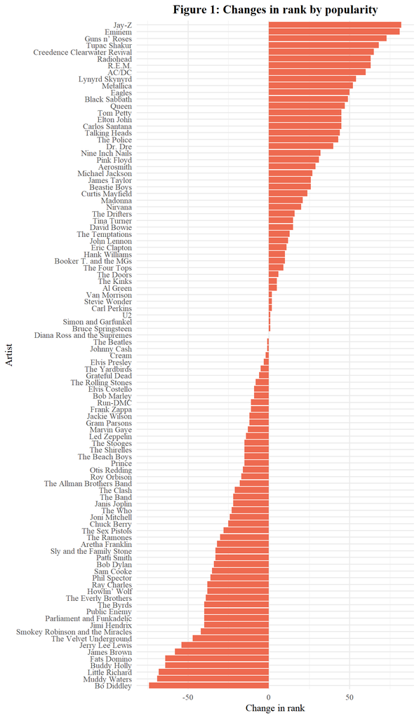

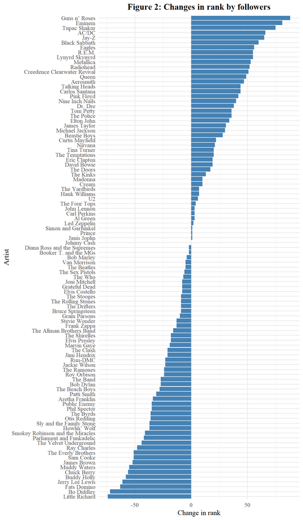

To investigate which characteristics explain these changes in popularity, I estimated two linear regression models. Figure 3 shows the correlation matrix of the possible independent variables. I decided to exclude mean loudness and mean acousticness from the equations since they are strongly correlated with mean energy. I also excluded categorical variables such as genre and key to avoid high dimensionality and overfitting.

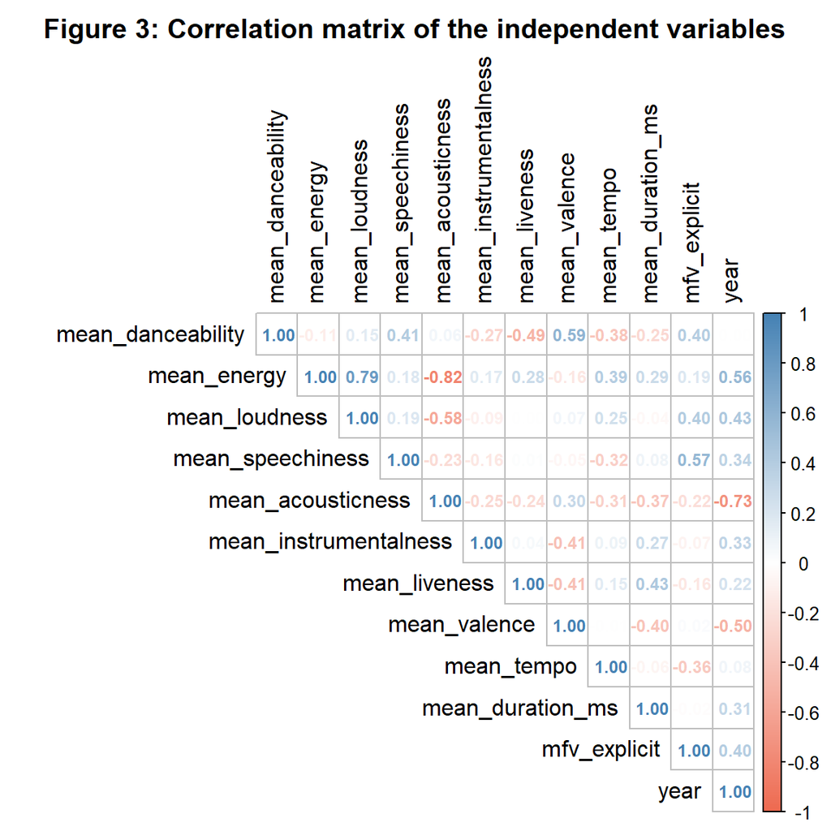

I estimated the same model twice using changes in rank as measured by popularity and the number of followers as the dependent variables. The models meet the assumptions of linear regression. Figure 4 shows the scaled coefficients of the two models with 95% confidence intervals. The coefficients suggest artists whose tracks score high one valence and speechiness (ie. are happy and have a lot of spoken words) have become less popular over the past decade. Moreover, artists whose majority of tracks are explicit have become more popular. Additionally, younger artists with more danceable tracks have likely become more popular - the coefficients for these variables are only marginally insignificant. The rest of the coefficients are not statistically significant.

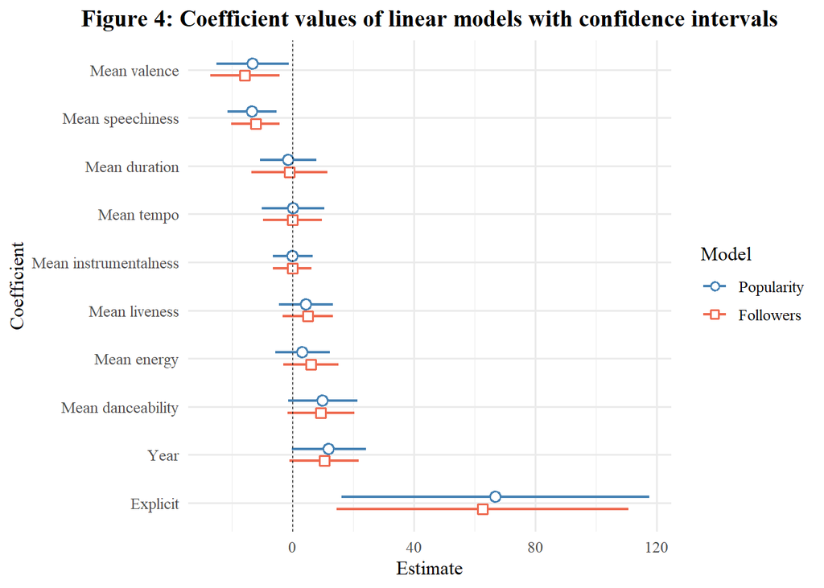

Finally, Figure 5 depicts the average changes in rank by genre. Heavy metal and hip hop artists have become more popular, and blues and soul artists have become less popular. This pattern is consistent with the results of the linear models. Hip hop and heavy metal artists tend to have more explicit tracks, which are often sadder (hip hop artists often come from disadvantaged backgrounds, which their music reflects). Blues and soul artists tend to be older and produce happier but less danceable tracks (they are generally quite slow).

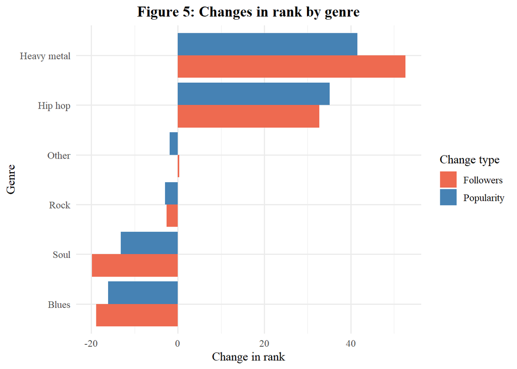

## Code Appendix

```r
knitr::opts_chunk$set(echo = FALSE, warning = FALSE, message = FALSE, include = FALSE, output = FALSE)
library(spotifyr)
library(tidyverse)
library(rvest)
library(statip)
library(forcats)
library(ggplot2)
library(jtools)
library(RSelenium)
library(netstat)
library(corrplot)
library(car)

# Step 1: Scrape the names ------------------------------------------------
# I set eval = FALSE for chunks I ran only once

# read the html code of the websites
magasine_html_bottom <- read_html("https://www.rollingstone.com/music/music-lists/100-greatest-artists-147446")
magasine_html_top <- read_html("https://www.rollingstone.com/music/music-lists/100-greatest-artists-147446/the-band-2-88489/")

# first 50 artists
artist_names_bottom_50 <- magasine_html_bottom %>%
    html_elements(xpath = '//*[@id="post-147446"]/div[1]/div/article/div[3]') %>%
    html_elements("h2") %>%
    html_text()

# last 50 artists
artist_names_top_50 <- magasine_html_top %>%
    html_elements(xpath = '//*[@id="post-147446"]/div[1]/div/article/div[3]') %>%
    html_elements("h2") %>%
    html_text()

# add the two lists together, reverse the order of the list
artist_names <- c(artist_names_bottom_50, artist_names_top_50) %>%
  rev()

# save the artist list
artist_names <- as.data.frame(artist_names)
write.csv(artist_names, "data/artist_names.csv", row.names = FALSE)

# Step 2: Get the Spotify data --------------------------------------------

# get the access token
client_id <- Sys.getenv("SPOTIFY_CLIENT_ID")
client_secret <- Sys.getenv("SPOTIFY_CLIENT_SECRET")
access_token <- get_spotify_access_token(client_id, client_secret)

# for each artist in the list, get the audio features
# I sliced data into 5 slices to meet the API restrictions
# and ran script for one slice per day
slice_1 <- 1:20
slice_2 <- 21:40
slice_3 <- 41:60
slice_4 <- 61:80
slice_5 <- 81:100

top_artists_tracks <- data.frame()

# get the artist audio features
# I changed the slice in the for loop
for (i in slice_1){
  tryCatch({
    artist_tracks <- get_artist_audio_features(artist_names[i])
    top_artists_tracks <- rbind(top_artists_tracks, artist_tracks)
  }, error = function(e) {
    print(paste(artist_names[i], "not found"))
  })
}

# delete some columns and save data as a csv file
# each of the 5 csv files corresponds to one slice
top_artists_tracks <- top_artists_tracks %>%
  select(-album_images, -artists, -available_markets)
write.csv(top_artists_tracks, "data/top_artists_tracks_1.csv", row.names = FALSE)

# parliament and funkadelic not found, so I run the same code using
# a slightly different band name
parfun <- get_artist_audio_features("Parliament Funkadelic") %>%
  select(-album_images, -artists, -available_markets)

# save parliament and funkadelic data
write.csv(parfun, "data/parfun.csv", row.names = FALSE)

# neil young not found, but I was unable to retrive the data using a different name
# or the artist id, so I decided to leave it out

# load all data and merge into one dataframe
top_artists_tracks <- data.frame()
for (i in 1:5){
  file_path = paste0("data/top_artists_tracks_", i, ".csv")
  current_tracks <- read_csv(file_path)
  top_artists_tracks <- rbind(top_artists_tracks, current_tracks)
}
parfun <- read_csv("data/parfun.csv")
top_artists_tracks <- rbind(top_artists_tracks, parfun)

# get data on artist followers and popularity
artist_ids <- unique(top_artists_tracks$artist_id)
top_artists_pop <- data.frame()
for (id in artist_ids){
  artist_pop <- get_artist(id)
  followers <- artist_pop$followers$total
  popularity <- artist_pop$popularity

  artist_df <- data.frame(artist_id = id, followers = followers, popularity = popularity)
  top_artists_pop <- rbind(top_artists_pop, artist_df)
}

# save data
write.csv(top_artists_pop, "data/top_artists_pop.csv", row.names = FALSE)

# Step 3: Scrape wiki data ------------------------------------------------

find_position <- function(html, keyword){
  #' This function searches for a keyword within an HTML document
  #' and returns the position of the first occurrence.
  #'
  #' @param html The HTML document to search within.
  #' @param keyword The keyword to search for.
  #'
  #' @return The position of the first occurrence of the keyword
  #' within the HTML document, or NA if not found.

  positions <- html %>%
    html_elements(css = ".infobox.vcard > tbody > tr") %>%
    html_text() %>%
    str_detect(keyword)

  tryCatch(pos <- which(positions == TRUE)[1] %>% as.character(), error = function(e) pos <- NA)
  return(pos)
}

# load the artist list
artist_names <- read.csv("data/artist_names.csv")
artist_names <- artist_names$artist_names

# change names to avoid confusion
artist_names[artist_names == "Prince"] <- "Prince (musician)"
artist_names[artist_names == "Nirvana"] <- "Nirvana (band)"
artist_names[artist_names == "Queen"] <- "Queen (band)"
artist_names[artist_names == "Parliament and Funkadelic"] <- "Parliament-Funkadelic"
artist_names[artist_names == "Cream"] <- "Cream (band)"
artist_names[artist_names == "Eagles"] <- "Eagles (band)"

# initialise the df
genres_years <- data.frame()

# start the browser
rD <- rsDriver(browser=c("firefox"), port = free_port(random = TRUE), chromever = NULL)
driver <- rD$client
driver$navigate("https://en.wikipedia.org/wiki/Main_Page")

# iterate over the artist list
for (artist in artist_names){

  # search for the artist
  driver$findElement(using = "class name", 'cdx-text-input__input')$clearElement()
  driver$findElement(using = "class name", 'cdx-text-input__input')$sendKeysToElement(
    list(artist, key = "enter"))
  Sys.sleep(2)

  # get the artist page, find the position of the "Genres" and "Years" rows
  artist_html <- read_html(driver$getCurrentUrl()[[1]])
  genres_pos <- find_position(artist_html, "Genres")
  years_pos <- find_position(artist_html, "Years")

  # get the genres and years based on position
  genres <- artist_html %>%
        html_elements(css = paste0(".infobox.vcard > tbody > tr:nth-child(", genres_pos, ") > td >
                                   div > ul > li:nth-child(1)")) %>%
        html_text()
  if (length(genres) == 0){
    genres <- artist_html %>%
        html_elements(css = paste0(".infobox.vcard > tbody > tr:nth-child(", genres_pos, ") > td")) %>%
        html_text()
  }
  years <- artist_html %>%
        html_elements(css = paste0(".infobox.vcard > tbody > tr:nth-child(", years_pos, ") > td")) %>%
        html_text()
```

```r
  # add the data to the df
  genres_years <- rbind(genres_years, c(artist, genres, years))
}

# close the browser
driver$close()
rD$server$stop()

# change the names and clean three year entries manually
names(genres_years) <- c("artist", "genre", "year")
genres_years$year[40] <- "1956"
genres_years$year[60] <- "1975"
genres_years$year[82] <- "1968"

# clean the data
genres_years_clean <- genres_years %>%
  mutate(
    # delete enters from year, trim,take the first four characters, turn into numeric
    year = str_replace_all(year, "\n", "") %>% str_trim() %>% str_sub(1, 4) %>% as.numeric(),
    # delete references and enters from genre, trim
    genre = str_replace_all(genre, "\\[.*\\]", "") %>% str_replace_all("\n", "") %>% str_trim()) %>%
  # make categories for genre more general
  mutate(genre = case_when(str_detect(genre, "Hard rock") ~ "Heavy metal",
                           str_detect(genre, "Blues rock") ~ "Blues",
                           str_detect(genre, "rock") ~ "Rock",
                           str_detect(genre, "blues") ~ "Blues",
                           str_detect(genre, "R&B") ~ "Blues",
                           str_detect(genre, "soul") ~ "Soul",
                           str_detect(genre, "hip hop") ~ "Hip hop",
                           str_detect(genre, "country") ~ "Country",
                           str_detect(genre, "Rockabilly") ~ "Rock and roll",
                           str_detect(genre, "punk") ~ "Punk",
                           T ~ genre)) %>%
  # gather all categories with <5 entries into "Other"
  mutate(genre = case_when(str_detect(genre, "Heavy metal") ~ "Heavy metal",
                           str_detect(genre, "Rock") ~ "Rock",
                           str_detect(genre, "Blues") ~ "Blues",
                           str_detect(genre, "Soul") ~ "Soul",
                           str_detect(genre, "Hip hop") ~ "Hip hop",
                           str_detect(genre, "Rock and roll") ~ "Rock and roll",
                           T ~ "Other"))

# change the artist names back to original
artist_names <- read.csv("data/artist_names.csv")
artist_names <- artist_names$artist_names
genres_years_clean$artist <- artist_names

# write the data
write.csv(genres_years_clean, "data/genres_years.csv", row.names = FALSE)

# Step 4: Merge data ------------------------------------------------------

# load artist names, popularity and genres + years data
artist_names <- read.csv("data/artist_names.csv")
artist_names <- artist_names$artist_names
top_artists_pop <- read_csv("data/top_artists_pop.csv")
genres_years <- read_csv("data/genres_years.csv")

# exclude "Neil Young" from the list of artist names
artist_names_complete <- artist_names[!artist_names %in% c("Neil Young")]

# create a name and rank dataframe
artist_names_rank <- data.frame(artist_name = artist_names_complete, rank_2010 = 1:99)

# summarise the data by artist
# top_artists_tracks was loaded earlier in step 2
top_artists_summary <- top_artists_tracks %>%
  select(artist_name, artist_id, danceability, energy, loudness, speechiness, acousticness,
         instrumentalness, liveness, valence, tempo, duration_ms,
         explicit, time_signature, key_name, mode_name) %>%
  group_by(artist_name, artist_id) %>%
  summarise(mean_danceability = mean(danceability, na.rm = TRUE),
            mean_energy = mean(energy, na.rm = TRUE),
            mean_loudness = mean(loudness, na.rm = TRUE),
            mean_speechiness = mean(speechiness, na.rm = TRUE),
            mean_acousticness = mean(acousticness, na.rm = TRUE),
            mean_instrumentalness = mean(instrumentalness, na.rm = TRUE),
            mean_liveness = mean(liveness, na.rm = TRUE),
            mean_valence = mean(valence, na.rm = TRUE),
            mean_tempo = mean(tempo, na.rm = TRUE),
            mean_duration_ms = mean(duration_ms, na.rm = TRUE),
            mfv_explicit = mfv1(explicit),
            mfv_time_signature = mfv1(time_signature),
            mfv_key_name = mfv1(key_name),
            mfv_mode_name = mfv1(mode_name))

# add rank to the summary
top_artists_summary <- top_artists_summary %>%
  left_join(artist_names_rank, by = "artist_name")

# check which are missing
notmissing <- top_artists_summary %>%
  filter(!is.na(rank_2010))
notmissing <- notmissing$artist_name

missing <- top_artists_summary %>%
  filter(is.na(rank_2010))
missing <- missing$artist_name

# exclude notmissing from artist_names_complete
artist_names_wrong <- artist_names_complete[!artist_names_complete %in% notmissing]

# compare
artist_names_wrong
missing

# correct the names
top_artists_summary <- top_artists_summary %>%
  mutate(artist_name = case_when(artist_name == "2Pac" ~ "Tupac Shakur",
                                 artist_name == "Allman Brothers Band" ~ "The Allman Brothers Band",
                                 artist_name == "Bob Marley & The Wailers" ~ "Bob Marley",
                                 artist_name == "Booker T. & the M.G.'s" ~  "Booker T. and the MGs",
                                 artist_name == "Diana Ross & The Supremes" ~ "Diana Ross and the Supremes",
                                 artist_name == "Four Tops" ~ "The Four Tops",
                                 artist_name == "Guns N' Roses" ~ "Guns n’ Roses",
                                 artist_name == "Hank Williams, Jr." ~ "Hank Williams",
                                 artist_name == "Howlin' Wolf" ~ "Howlin’ Wolf",
                                 artist_name == "JAY-Z" ~ "Jay-Z",
                                 artist_name == "Parliament Funkadelic" ~ "Parliament and Funkadelic",
                                 artist_name == "Ramones" ~ "The Ramones",
                                 artist_name == "Run–D.M.C." ~ "Run-DMC",
                                 artist_name == "Santana" ~ "Carlos Santana",
                                 artist_name == "Sex Pistols" ~ "The Sex Pistols",
                                 artist_name == "Simon & Garfunkel" ~ "Simon and Garfunkel",
                                 artist_name == "Sly & The Family Stone" ~ "Sly and the Family Stone",
                                 artist_name == "Smokey Robinson & The Miracles" ~
                                   "Smokey Robinson and the Miracles",
                                 TRUE ~ artist_name)) %>%
  select(-rank_2010) %>%
  left_join(artist_names_rank, by = "artist_name")
```

```r
# sort ids by popularity
most_popular <- top_artists_pop %>%
  select(artist_id, popularity) %>%
  arrange(desc(popularity)) %>%
  mutate(rank_pop = row_number())

# sort ids by followers
most_followed <- top_artists_pop %>%
  select(artist_id, followers) %>%
  arrange(desc(followers)) %>%
  mutate(rank_fol = row_number())

# add popularity and followers to the summary
# compute changes in rank
top_artists_summary <- top_artists_summary %>%
  left_join(most_popular, by = "artist_id") %>%
  left_join(most_followed, by = "artist_id") %>%
  left_join(genres_years, c("artist_name" = "artist")) %>%
  mutate(change_pop = rank_2010 - rank_pop,
         change_fol = rank_2010 - rank_fol)

# Step 5: Plot ------------------------------------------------------------

# barplots with position changes
top_artists_summary %>%
  ggplot(aes(x = fct_reorder(artist_name, change_pop), y = change_pop)) +
  geom_bar(stat = "identity", fill = "coral2") +
  coord_flip() +
  labs(x = "Artist", y = "Change in rank", title = "Figure 1: Changes in rank by popularity") +
  theme_minimal(base_size = 12, base_family = "serif") +
  theme(plot.title = element_text(hjust = 0.5, face = "bold"))

top_artists_summary %>%
  ggplot(aes(x = fct_reorder(artist_name, change_fol), y = change_fol)) +
  geom_bar(stat = "identity", fill = "steelblue") +
  coord_flip() +
  labs(x = "Artist", y = "Change in rank", title = "Figure 2: Changes in rank by followers") +
  theme_minimal(base_size = 12, base_family = "serif") +
  theme(plot.title = element_text(hjust = 0.5, face = "bold"))

# plot the correlation matrix
cor_plot <- cor(top_artists_summary[, c(3:13, 23)], use = "complete.obs") %>%
  corrplot(type = "upper", method = "number", tl.col = "black",
           col=colorRampPalette(c('coral2', 'white', 'steelblue'))(200),
           title = "Figure 3: Correlation matrix of the independent variables", mar=c(0,0,2,0), number.cex = 0.75)

# linear models
m_pop <- lm(change_pop ~ mean_danceability + mean_energy + mean_speechiness +
              mean_instrumentalness + mean_liveness + mean_valence +
              mean_tempo + mean_duration_ms + mfv_explicit + year, data = top_artists_summary)
m_fol <- lm(change_fol ~ mean_danceability + mean_energy + mean_speechiness +
              mean_instrumentalness + mean_liveness + mean_valence +
              mean_tempo + mean_duration_ms + mfv_explicit + year, data = top_artists_summary)

# vif tests for multicollinearity
vif(m_fol)
vif(m_pop)

# heteroscedasticity tests
ncvTest(m_fol)
ncvTest(m_pop)

# variance constancy
plot(m_fol, 3)
plot(m_pop, 3)

# normality of residuals
hist(residuals(m_fol))
hist(residuals(m_pop))

# change the names of the coefficients and their order
coef_named = c("Mean valence" = "mean_valence", "Mean speechiness" = "mean_speechiness",
               "Mean duration" = "mean_duration_ms", "Mean tempo" = "mean_tempo",
               "Mean instrumentalness" = "mean_instrumentalness", "Mean liveness" = "mean_liveness",
               "Mean energy" = "mean_energy", "Mean danceability" = "mean_danceability",
               "Year" = "year", "Explicit" = "mfv_explicitTRUE")

# plot the linear models
plot_summs(m_pop, m_fol, model.names = c("Popularity", "Followers"),
           robust = TRUE, scale = TRUE, coefs = coef_named, colors = c('steelblue', 'coral2')) +
  labs(title = "Figure 4: Coefficient values of linear models with confidence intervals",
       x = "Estimate", y = "Coefficient") +
  theme_minimal(base_size = 12, base_family = "serif") +
  theme(plot.title = element_text(hjust = 0.5, face = "bold"))

# calculate the position changes by genre
genre_changes <- top_artists_summary %>%
  group_by(genre) %>%
  summarise(mean_change_pop = mean(change_pop, na.rm = TRUE),
            mean_change_fol = mean(change_fol, na.rm = TRUE)) %>%
# turn to long format
  pivot_longer(cols = c(mean_change_pop, mean_change_fol), names_to = "change_type", values_to = "change") %>%
  mutate(change_type = if_else(change_type == "mean_change_pop", "Popularity", "Followers"))

# plot the position changes by genre
# include both popularity and followers
genre_changes %>%
  ggplot(aes(fill = change_type, y = change, x = fct_reorder(genre, change))) +
  geom_bar(stat = "identity", position = "dodge") +
  coord_flip() +
  labs(x = "Genre", y = "Change in rank", title = "Figure 5: Changes in rank by genre") +
  scale_fill_manual("Change type", values = c('coral2','steelblue')) +
  theme_minimal(base_size = 12, base_family = "serif") +
  theme(plot.title = element_text(hjust = 0.5, face = "bold"))
```